# Rock Climbing V Grades Study

What are the greatest contributing factors to someones maximum climbing ability?

We chose the Climbs.csv dataset we found online as we are both avid climbers. We had to clean the data very intensively as not many people answered the questions in the same formatting. This included removing almost half of the columns that were so bad they could not be saved. What we ended up with was very useful and exciting data.

**Now with clean data we wanted to explore many things such as:**

- Ape index vs Max V Grade
- Correlation of training on Max V Grade
- BMI within V grades

We ended up mainly talk about Max V Grade instead of sport grade because there were way more boulderers who took the survey.

**New skills learned:**

- We learned how to get bullet points in the dashboard
- Found Violin plot for a cool way to show data
- Spider plot because it condensed our findings
- css to fix weird formatting in the dashboard
- Not new but we used all the skills learned in class

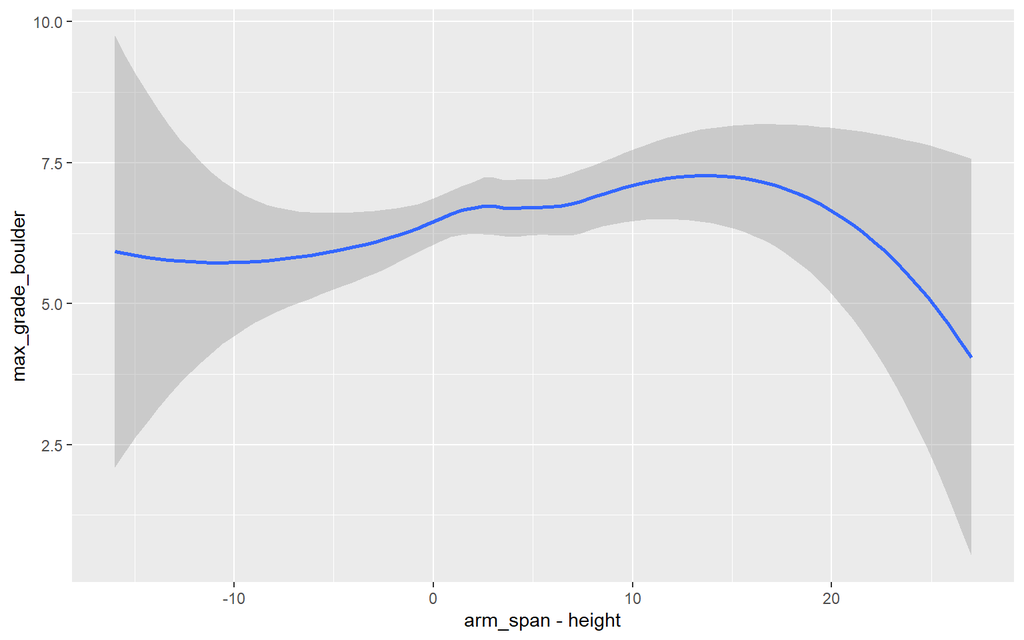

The plot above shows a simple geom smooth graph of ape index on max v grade, there appears to be no noticeable correlation. The plot below is a violin and jitter plot showing the density of BMI in every V grade to see if there is a theoretical perfect BMI. It appears to taper inward to a value near 23 but more data would help concrete these findings.

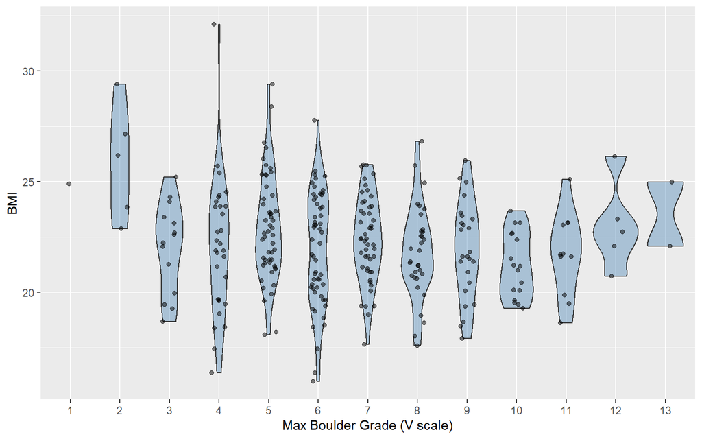

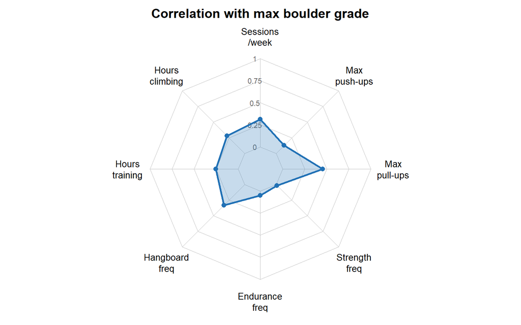

Training Variables vs Max Boulder Grade

Select variables:

Sessions/week

Hours climbing

Hours training

Hangboard freq

Endurance freq

Strength freq

Max pull-ups

Max push-ups

Surprisingly there seemed to be no correlation between max boulder grade and a persons ape index, dispite many existing myths in the climbing community. So we turned to other predictors, BMI seemed promising as our violin graphs did show a tapering to a specific BMI of around 22-23 however we knew a better predictor existed.

This is a link to the dataset we used [Our Data :)](https://docs.google.com/spreadsheets/d/1J6d45EqIlIsIqNdi2X-Zl-EGFxf9d9T3R_W55xrpEAs/edit?gid=1650492946#gid=1650492946)

If you would like to learn more, here are some additional resources that will be helpful

- [Sport Climbing Predictors](https://latticetraining.com/blog/what-is-the-number-1-measure-of-performance-for-sport-climbers)
- [Additional Pullup Data](https://www.powercompanyclimbing.com/blog/heatmaps)
- [Climber Data](https://www.kaggle.com/datasets/jordizar/climb-dataset)